# ENGR 441: Physical Acoustics Homework #2

### Due: Friday, February 20 at 5:00PM

Problems marked with [*] are potential sources for quiz questions.

### Problem 1. Coefficient of friction oscillator:

Two cylindrical rollers are located a distance 2a apart. Their bearings are anchored. The rollers rotate at an angular speed ωr in opposite directions, as shown in the figure below. On the top of the rollers rests a uniform bar of length, ℓ, and weight, W = mg. Assuming a dry coefficient of-friction µ between the rollers and the bar, the bar will oscillate back and forth longitudinally executing simple harmonic motion. Video and description of this system:

https://www.youtube.com/watch?v=46lk2FXzwT8

The restoring force will be the difference between the frictional forces in the x direction, Fx (along the bar), due to the uneven weight distribution of the bar when it is displaced from equilibrium. Calculate the frequency of oscillation of the bar’s oscillations when the wheels rotate as shown in the figure below.

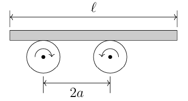

### Problem 1 Solution:

This problem shouldn't be too bad especially after having some tips and tricks taught in class. The way this works is that as these wheels rotate, they will apply friction to the bar where the normal force resides. The normal force will increase on one side depending on how much the bar is displaced relative to the middle of it. We can call the middle of the system 0 like the origin of a coordinate axis. If one side is displaced a distance x then the other side is displaced as well a distance -x. Which ever side of the bar has the greater displacement then it will have a greater normal force and therefore have a higher force of friction acting on it. This then moves it back to equilibrium. This goes on and on as the wheels spin resulting in a harmonic oscillator. Now we can dive into the math.

I'm going off memory from the explanation from class so bear with me. We can start with defining an equation for the mass in relation to the mid point and the end of one side of the bar. Defining right as the positive x direction we get: $$m_{R} = \lambda(\frac{l}{2}+x)$$

For this equation we have x as the displacement, l/2 to define the mid point, and lambda to represent the mass per unit length $\lambda = \frac{m}{l}$. Since we described right as positive x then the left side will be similar just with a negative sign: $$m_{L} = \lambda(\frac{l}{2}-x)$$

So we have these two, but how do we get to frequency? Lets write down some equations so that there are some options. $f = 1/T$, $f = \omega / 2\pi$, $\omega = 2\pi/T$, and from lab 1 $\omega_{0} = \sqrt{g/L}$ where $\omega$ is the angular frequency. Now we can continue with the plan. Since the forces in the y direction cancel we can write the sum of the forces in the x direction. We can define the normal force as $N = \lambda * g$. With this the force due to kinetic friction is $F_{k} = \mu \lambda g$. Now we can write out the full equation: $$\mu \lambda g(\frac{l}{2} - x) - \mu \lambda g(\frac{l}{2} + x) = m\frac{d^{2}x}{dt^{2}}$$

Once we expand the mass per unit length term and then do some algebra we can get the acceleration in whatever direction the bar is moving: $$\frac{d^{2}x}{dt^{2}} = -\frac{2\mu g}{l}x$$

This is great because the right side of the equation looks like one of the equations written down above. We can think of most of the entire right side as the angular frequency. Angular frequency in this case being $\omega = \sqrt{\frac{2\mu g}{l}}$. This will give us an equation like this after dragging the square root over: $$\frac{d^{2}x}{dt^{2}} = -\omega^{2}x$$

Since the term on the right is just the second derivative of position over time we can just write this as the acceleration (a). Frequency and angular frequency are related by this equation, $f = \omega/2\pi$. I wrote this in a difficult way but we are trying to get to frequency at some point. Since this is the case we can sub this in: $$a = -4\pi^{2}f^{2}x$$

Now we just have to get the frequency to the other side. After doing this on paper I found: $$f = -\sqrt{\frac{a}{4\pi^{2}x}}$$

This doesn't seem right to me though.

### Problem 2.[*] U-tube oscillations:

The tube shown in the figure below is filled with a liquid that has a uniform mass density, ρ. The total length of the fluid column is L, and the cross-sectional area of the tube, S, is constant. When the fluid is displaced from its equilibrium position by a distance, x (as shown), the column of liquid executes simple harmonic motion under the influence of a constant gravitational acceleration, g.

#### 2a: (Period) Calculate the period, T, of the oscillations, neglecting damping.

#### 2b: (Quality factor) If the oscillations are observed to decrease by 20% during each cycle, calculate Q.

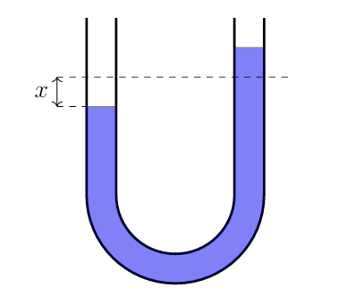

### Problem 2 [*] Solution:

Remember the equations above for period, frequency, etc. The quality factor is given by $Q = \frac{m\omega_{0}}{R_{m}}$. I have a feeling this one is similar to the last one, but in the y direction now. The question I have now is that is it reasonable to neglect the curve in the tube? We could calculate the total volume of the fluid column and then it would kind of look like a spring problem in a way. In this case however the force on the side of the tube that has the most liquid will be determined by the changing mass since it will lose fluid as it flows to the other side trying to balance out.

On the right side of the general equation Ill eventually have we can go ahead and write down newton's second law and leave it there for a minute. Now the sum of the forces comes in for both sides like the last problem. I will ignore the curve so that I stop trying to consider it. I believe that the uniform mass density ($\rho$) can act as the mass per unit length ($\lambda$) did in the last problem.

I'm trying to write this down on paper at the moment and I'm stuck. I tried to write $\rho$ like the mass per unit length from last problem and it just isnt working out. We march on though.

Okay total volume (V) is going to be $V = LS$. Splitting the tube down the middle so separate the sides we can find the volume of one side in relation to the displacement. Up is + and down is -. If we say the equilibrium position is 0 and we displace one side by x, then the total displacement on the big side is 2x. Multiplying this by the cross sectional area, the total volume displaced is: $$V = 2xS$$

We need the total mass displaced and this is where $\rho$ comes in. Multiplying the volume displaced by the density we get the mass of the liquid that was displaced an amount x. So $m = \rho V$. We can expand this and say that: $$m = 2\rho xS$$

Now that we have this we can move on and apply gravity to this case. This will give us the force applied to the side with less liquid caused by the side with more. This problem and the last look like the 2nd order diff equation in the lab that is not solvable analytically. I'll go ahead and write $\frac{d^{2}x}{dt^{2}}$ as just $a$.

For the force we just multiply the mass from above times g. Now we can set newton's second law from earlier equal to this. $$ma = 2\rho xSg$$

Here I got kind of lost until I figured out a way to cancel some terms. This way I can try to get the angular frequency out of it $\omega = \sqrt{g/L}$. I figured that I found the total mass to be equal to the density times total length times the cross sectional area. If we plug this in for mass (m) then we can rearrange the equation and then cancel terms. This will leave us with: $$-\frac{2xg}{L} = a$$

The left side is negative because the force pushing the side with more liquid down. BUT LOOK!! We now have something that relates to frequency. Lets substitute in the angular acceleration: $$a = -\omega^{2} x$$

From the equations in the first problem I know an equation that relates angular frequency to the period. After some algebra on paper to solve for the period from the angular frequency, we have this $T = 2\pi\sqrt{\frac{L}{2g}}$. I thought this was good, but it wasn't. I did more algebra to find a direct plug in for the omega.

It shouldn't have taken as long as it did, but eventually I just stopped trying so hard. Heres what I have: $$a = -\frac{4\pi^{2}}{T^{2}}x$$

Solving for T I get: $$T = -\sqrt{\frac{4\pi^{2}}{a}x}$$

This still doesn't look right to me.

### Problem 3. Critical Damping:

$1/\tau = \omega_{0}$

Recall for critical damping the condition and general solution: $$\eta = -1/\tau \pm 0 (repeated\space root!),-->x(t) = (C_{1} + C_{2}t)e^{-t/\tau}$$

#### Problem 3 Part a:

Determine the constants $C_{1}$ and $C_{2}$ in terms of the initial conditions $x(0) = x_{0}$ and $u(0) = u_{0}$ at t = 0.

#### Problem 3 Part b:

For appropriate values of m, k, and $R_{m}$ create plots over appropriate time scales of the following pairs of initial conditions:

(i): $x_{0} = 0m$ and $u_{0} = 1m/s$

(ii): $x_{0} = 1m$ and $u_{0} = 0m/s$

(iii): $x_{0} = 0.5m$ and $u_{0} = 0.5m/s$

### Problem 3 Solution:

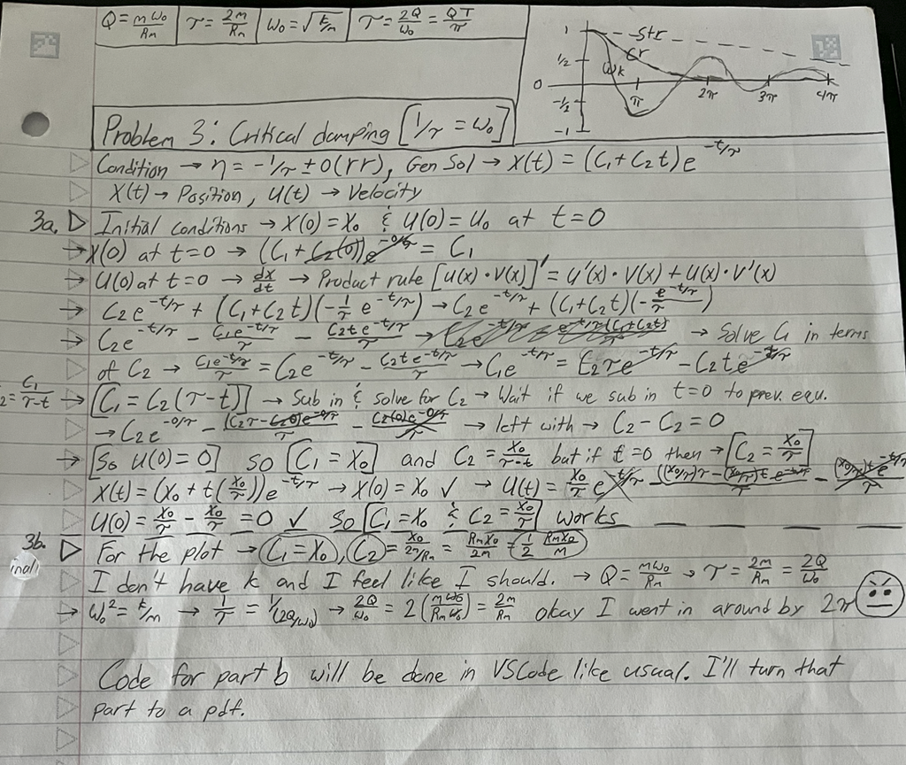

```
(i) $x_0 = 0$ m, $u_0 = 1$ m/s
  C₁ = 0.000
  C₂ = 1.000
  x(t) = (0.000 + 1.000t)e^(-t/0.316)
  Final position as t→∞: 0.000 m (exponential decay to zero)

(ii) $x_0 = 1$ m, $u_0 = 0$ m/s
  C₁ = 1.000
  C₂ = 3.162
  x(t) = (1.000 + 3.162t)e^(-t/0.316)
  Final position as t→∞: 0.000 m (exponential decay to zero)

(iii) $x_0 = 0.5$ m, $u_0 = 0.5$ m/s
  C₁ = 0.500
  C₂ = 2.081
  x(t) = (0.500 + 2.081t)e^(-t/0.316)
  Final position as t→∞: 0.000 m (exponential decay to zero)
```

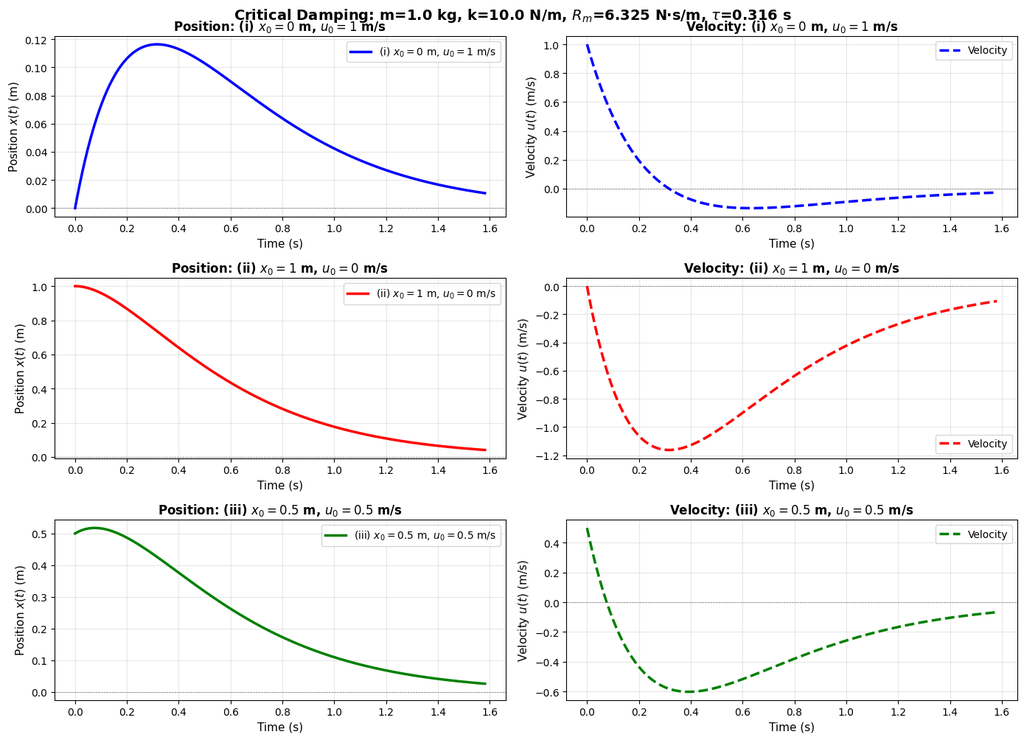

[output not shown]

```python
# Problem 3 Part b: Critical Damping Plots
# Code created with assistance from GitHub Copilot ********

import numpy as np
import matplotlib.pyplot as plt

# Physical parameters
m = 1.0          # mass in kg
k = 10.0         # spring constant in N/m
omega_0 = np.sqrt(k / m)  # natural angular frequency

# Critical damping condition: 1/tau = omega_0
tau = 1 / omega_0

# Critical damping resistance
R_m = 2 * m * omega_0  # R_m = 2*m/tau for critical damping

# Time array (0 to ~5 time constants)
t = np.linspace(0, 5*tau, 1000)

# Constants from part (a):
# C1 = x_0
# C2 = u_0 + x_0/tau

# Three cases of initial conditions
cases = [
    {'x0': 0.0, 'u0': 1.0, 'label': '(i) $x_0 = 0$ m, $u_0 = 1$ m/s', 'color': 'blue'},
    {'x0': 1.0, 'u0': 0.0, 'label': '(ii) $x_0 = 1$ m, $u_0 = 0$ m/s', 'color': 'red'},
    {'x0': 0.5, 'u0': 0.5, 'label': '(iii) $x_0 = 0.5$ m, $u_0 = 0.5$ m/s', 'color': 'green'}
]

# Create the plot
plt.figure(figsize=(14, 10))

for i, case in enumerate(cases):
    x0 = case['x0']
    u0 = case['u0']

    # Calculate constants
    C1 = x0
    C2 = u0 + x0/tau

    # Calculate position: x(t) = (C1 + C2*t)*exp(-t/tau)
    x_t = (C1 + C2 * t) * np.exp(-t / tau)

    # Calculate velocity: u(t) = dx/dt
    u_t = C2 * np.exp(-t/tau) + (C1 + C2*t) * (-1/tau) * np.exp(-t/tau)
    u_t_simplified = (C2 - (C1 + C2*t)/tau) * np.exp(-t/tau)

    # Subplot for position
    plt.subplot(3, 2, 2*i + 1)
    plt.plot(t, x_t, case['color'], linewidth=2.5, label=case['label'])
    plt.axhline(y=0, color='k', linestyle='--', linewidth=0.5, alpha=0.5)
    plt.xlabel('Time (s)', fontsize=11)
    plt.ylabel('Position $x(t)$ (m)', fontsize=11)
    plt.title(f"Position: {case['label']}", fontsize=12, fontweight='bold')
    plt.grid(True, alpha=0.3)
    plt.legend(fontsize=10)

    # Subplot for velocity
    plt.subplot(3, 2, 2*i + 2)
    plt.plot(t, u_t_simplified, case['color'], linewidth=2.5, linestyle='--', label='Velocity')
    plt.axhline(y=0, color='k', linestyle='--', linewidth=0.5, alpha=0.5)
    plt.xlabel('Time (s)', fontsize=11)
    plt.ylabel('Velocity $u(t)$ (m/s)', fontsize=11)
    plt.title(f"Velocity: {case['label']}", fontsize=12, fontweight='bold')
    plt.grid(True, alpha=0.3)
    plt.legend(fontsize=10)

    # Print key information
    print(f"\n{case['label']}")
    print(f"  C₁ = {C1:.3f}")
    print(f"  C₂ = {C2:.3f}")
    print(f"  x(t) = ({C1:.3f} + {C2:.3f}t)e^(-t/{tau:.3f})")
    print(f"  Final position as t→∞: {0:.3f} m (exponential decay to zero)")

plt.tight_layout()
plt.suptitle(f'Critical Damping: m={m} kg, k={k} N/m, $R_m$={R_m:.3f} N·s/m, $\\tau$={tau:.3f} s',
             fontsize=14, fontweight='bold', y=1.00)
plt.subplots_adjust(top=0.96)
plt.show()

# Summary
print("\n" + "="*70)
print("CRITICAL DAMPING OBSERVATIONS:")
print("="*70)
print(f"• Natural frequency ω₀ = {omega_0:.3f} rad/s")
print(f"• Time constant τ = {tau:.3f} s")
print(f"• Critical damping condition: 1/τ = ω₀ ✓")
print(f"• Damping resistance R_m = {R_m:.3f} N·s/m")
print("\n• Case (i): Started from rest with velocity → overshoots then decays")
print("• Case (ii): Started from displacement with no velocity → monotonic decay")
print("• Case (iii): Mixed initial conditions → intermediate behavior")
print("\n• Critical damping returns to equilibrium FASTEST without overshooting!")
```

### Problem 4. Strong Damping:

$1/\tau > \omega_{0}$

Recall for strong damping the condition and general solution: $$\eta_{1} = -1/\tau + \sqrt{1/\tau^{2} - \omega_{0}^{2}} \space\space and \space\space \eta_{2} = -1/\tau - \sqrt{1/\tau^{2} - \omega_{0}^{2}}$$

General solution: $$x(t) = C_{1}e^{\eta_{1}t} + C_{2}e^{\eta_{2}t}$$

#### Problem 4 Part a:

Determine the constants $C_{1}$ and $C_{2}$ in terms of the initial conditions x(0) = x0 and u(0) = u0 at t = 0.

#### Problem 4 Part b:

For appropriate values of m, k, and $R_{m}$ create plots over appropriate time scales of the following pairs of initial conditions:

(i): $x_{0} = 0m$ and $u_{0} = 1m/s$.

(ii): $x_{0} = 1m$ and $u_{0} = 0m/s$.

(iii): $x_{0} = 0.5m$ and $u_{0} = 0.5m/s$.

### Problem 4 Solution:

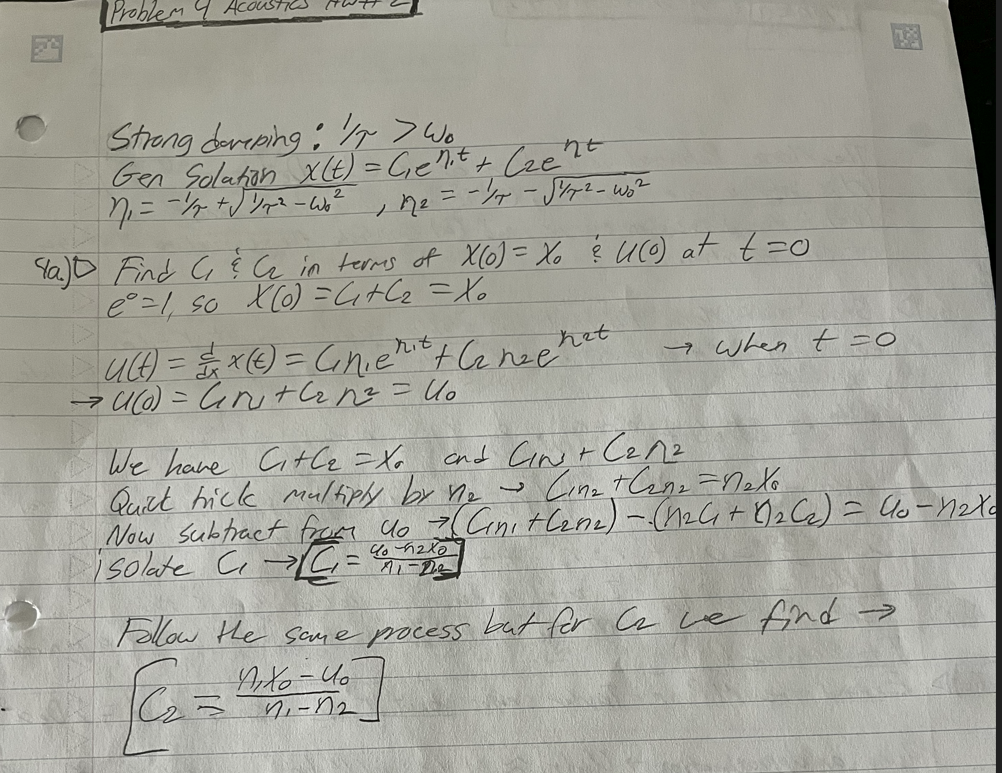

```
(i) $x_0 = 0$ m, $u_0 = 1$ m/s
  C₁ = 0.091
  C₂ = -0.091
  η₁ = -0.847 rad/s
  η₂ = -11.802 rad/s
  x(t) = 0.091e^(-0.847t) + -0.091e^(-11.802t)
  Final position as t→∞: 0.000 m (exponential decay to zero)

(ii) $x_0 = 1$ m, $u_0 = 0$ m/s
  C₁ = 1.077
  C₂ = -0.077
  η₁ = -0.847 rad/s
  η₂ = -11.802 rad/s
  x(t) = 1.077e^(-0.847t) + -0.077e^(-11.802t)
  Final position as t→∞: 0.000 m (exponential decay to zero)

(iii) $x_0 = 0.5$ m, $u_0 = 0.5$ m/s
  C₁ = 0.584
  C₂ = -0.084
  η₁ = -0.847 rad/s
  η₂ = -11.802 rad/s
  x(t) = 0.584e^(-0.847t) + -0.084e^(-11.802t)
  Final position as t→∞: 0.000 m (exponential decay to zero)
```

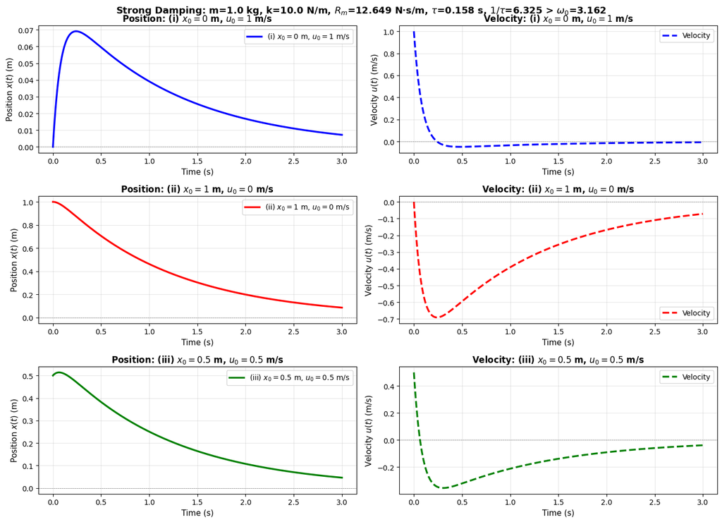

[output not shown]

```python
# Problem 4 Part b: Strong Damping Plots
# Code created with assistance from GitHub Copilot

import numpy as np
import matplotlib.pyplot as plt

# Physical parameters
m = 1.0          # mass in kg
k = 10.0         # spring constant in N/m
omega_0 = np.sqrt(k / m)  # natural angular frequency

# Strong damping condition: 1/tau > omega_0
# Let's choose tau such that 1/tau = 2*omega_0 (strongly damped)
tau = 1 / (2 * omega_0)

# Strong damping resistance
R_m = 2 * m / tau  # R_m = 2*m/tau

# Calculate eta values
eta_1 = -1/tau + np.sqrt((1/tau)**2 - omega_0**2)
eta_2 = -1/tau - np.sqrt((1/tau)**2 - omega_0**2)

# Time array (0 to longer time since strong damping is slower)
t = np.linspace(0, 3.0, 1000)

# Constants from part (a):
# C1 = (x0*eta2 - u0) / (eta2 - eta1)
# C2 = (u0 - x0*eta1) / (eta2 - eta1)

# Three cases of initial conditions
cases = [
    {'x0': 0.0, 'u0': 1.0, 'label': '(i) $x_0 = 0$ m, $u_0 = 1$ m/s', 'color': 'blue'},
    {'x0': 1.0, 'u0': 0.0, 'label': '(ii) $x_0 = 1$ m, $u_0 = 0$ m/s', 'color': 'red'},
    {'x0': 0.5, 'u0': 0.5, 'label': '(iii) $x_0 = 0.5$ m, $u_0 = 0.5$ m/s', 'color': 'green'}
]

# Create the plot
plt.figure(figsize=(14, 10))

for i, case in enumerate(cases):
    x0 = case['x0']
    u0 = case['u0']

    # Calculate constants
    C1 = (x0 * eta_2 - u0) / (eta_2 - eta_1)
    C2 = (u0 - x0 * eta_1) / (eta_2 - eta_1)

    # Calculate position: x(t) = C1*exp(eta1*t) + C2*exp(eta2*t)
    x_t = C1 * np.exp(eta_1 * t) + C2 * np.exp(eta_2 * t)

    # Calculate velocity: u(t) = dx/dt = C1*eta1*exp(eta1*t) + C2*eta2*exp(eta2*t)
    u_t = C1 * eta_1 * np.exp(eta_1 * t) + C2 * eta_2 * np.exp(eta_2 * t)

    # Subplot for position
    plt.subplot(3, 2, 2*i + 1)
    plt.plot(t, x_t, case['color'], linewidth=2.5, label=case['label'])
    plt.axhline(y=0, color='k', linestyle='--', linewidth=0.5, alpha=0.5)
    plt.xlabel('Time (s)', fontsize=11)
    plt.ylabel('Position $x(t)$ (m)', fontsize=11)
    plt.title(f"Position: {case['label']}", fontsize=12, fontweight='bold')
    plt.grid(True, alpha=0.3)
    plt.legend(fontsize=10)

    # Subplot for velocity
    plt.subplot(3, 2, 2*i + 2)
    plt.plot(t, u_t, case['color'], linewidth=2.5, linestyle='--', label='Velocity')
    plt.axhline(y=0, color='k', linestyle='--', linewidth=0.5, alpha=0.5)
    plt.xlabel('Time (s)', fontsize=11)
    plt.ylabel('Velocity $u(t)$ (m/s)', fontsize=11)
    plt.title(f"Velocity: {case['label']}", fontsize=12, fontweight='bold')
    plt.grid(True, alpha=0.3)
    plt.legend(fontsize=10)

    # Print key information
    print(f"\n{case['label']}")
    print(f"  C₁ = {C1:.3f}")
    print(f"  C₂ = {C2:.3f}")
    print(f"  η₁ = {eta_1:.3f} rad/s")
    print(f"  η₂ = {eta_2:.3f} rad/s")
    print(f"  x(t) = {C1:.3f}e^({eta_1:.3f}t) + {C2:.3f}e^({eta_2:.3f}t)")
    print(f"  Final position as t→∞: {0:.3f} m (exponential decay to zero)")

plt.tight_layout()
plt.suptitle(f'Strong Damping: m={m} kg, k={k} N/m, $R_m$={R_m:.3f} N·s/m, $\\tau$={tau:.3f} s, $1/\\tau$={1/tau:.3f} > $\\omega_0$={omega_0:.3f}',
             fontsize=13, fontweight='bold', y=1.00)
plt.subplots_adjust(top=0.96)
plt.show()

# Summary
print("\n" + "="*70)
print("STRONG DAMPING OBSERVATIONS:")
print("="*70)
print(f"• Natural frequency ω₀ = {omega_0:.3f} rad/s")
print(f"• Time constant τ = {tau:.3f} s")
print(f"• Strong damping condition: 1/τ = {1/tau:.3f} > ω₀ = {omega_0:.3f} ✓")
print(f"• Damping resistance R_m = {R_m:.3f} N·s/m")
print(f"• η₁ = {eta_1:.3f} rad/s (slower decay)")
print(f"• η₂ = {eta_2:.3f} rad/s (faster decay)")
print(f"• Both η values are REAL and NEGATIVE (no oscillation!)")
print("\n• Case (i): Started from rest with velocity → slow monotonic approach")
print("• Case (ii): Started from displacement → slow monotonic decay")
print("• Case (iii): Mixed initial conditions → slow monotonic decay")
print("\n• Strong damping: System is 'overdamped' - returns to equilibrium")
print("  SLOWER than critical damping, with NO oscillations!")
```

### Problem 5. [*]

Recall the displacement amplitude for the driven, damped, harmonic oscillator: $$A(\omega) = \frac{F}{\omega Z_{m}(\omega)},$$ where F is the amplitude of the force driving the system and, $$Z_{m}(\omega) = \sqrt{R_{m}^{2} + (m\omega - k/\omega)^{2}}$$

#### Problem 5 Part a:

At what drive frequency is the displacement amplitude a maximum?

#### Problem 5 Part b:

What is this drive frequency in terms of the quality factor, Q, and $\omega_{0}$?

### Problem 5 Solution:

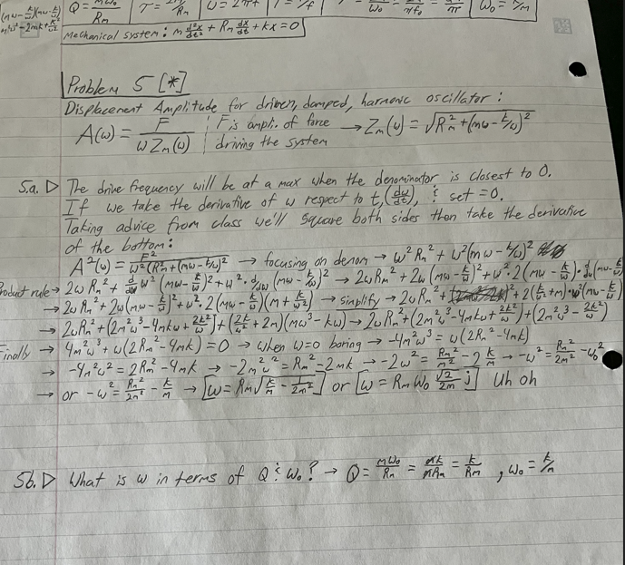

### Problem 6 Solution:

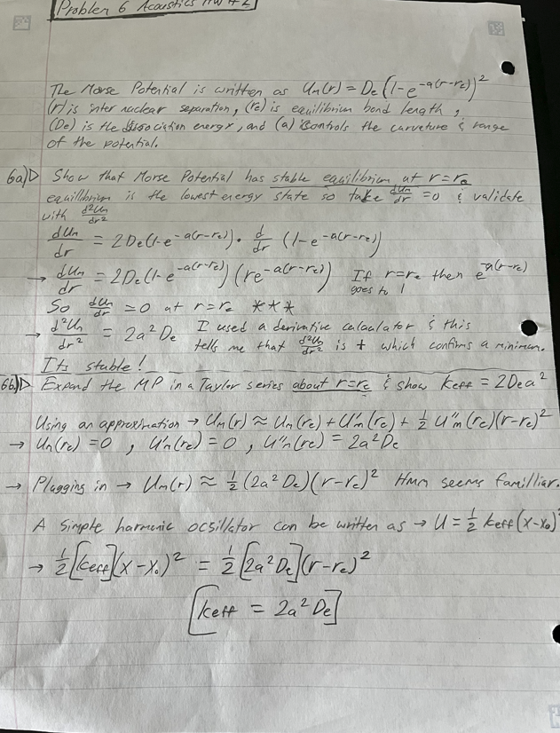